# L-GP Workflow

# Overview

This vignette illustrates one-dimensional empirical-Bayes smoothing with the L-GP prior. The main entry points are:

- `LGP_setup()`, which builds the design and penalty matrices.
- `ebnm_LGP_generator()`, which returns the model-fitting function.

This vignette focuses on the known-standard-error generator workflow. If `s` is unknown and you want to learn one common noise SD instead, see `eb_smoother()` in `00-overview.Rmd`.

# Identity-Link Example

The identity link is the simplest setting: the posterior summaries target the latent mean directly.

```r
set.seed(123)

t <- seq(0, 10, length.out = 150)
truth <- sin(t) + 0.3 * cos(1.5 * t)
s <- sample(c(0.15, 0.25, 0.4), length(t), replace = TRUE)
x <- truth + rnorm(length(t), sd = s)

setup_identity <- LGP_setup(
  t = t,
  p = 2,
  num_knots = 35,
  betaprec = 0,
  link = "identity"
)

fit_identity <- ebnm_LGP_generator(
  setup_identity,
  link = "identity"
)(x, s)

head(fit_identity$posterior)
```

```
#>        mean         var second_moment
#> 1 0.5518700 0.027751057     0.3323115
#> 2 0.5823227 0.020723582     0.3598233
#> 3 0.6124727 0.015590362     0.3907132
#> 4 0.6423201 0.011809011     0.4243841
#> 5 0.6718647 0.009051184     0.4604534
#> 6 0.7007504 0.007197660     0.4982488
```

```r
fit_identity$fitted_g
```

```
#> $scale
#> [1] 0.6414984
#>
#> $beta
#> [1] 0.5518700 0.4560005
#>
#> $beta_prec
#> [1] 0
#>
#> attr(,"class")
#> [1] "LGP"
```

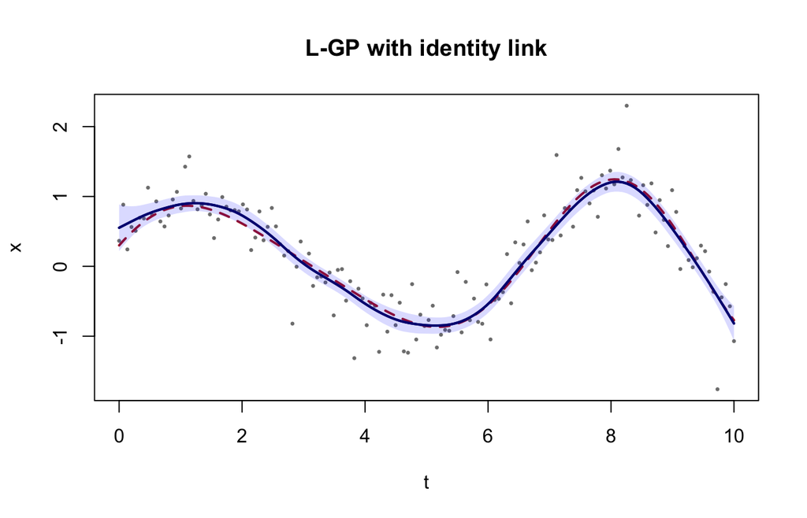

```r
plot(t, x, pch = 16, cex = 0.45, col = "grey50",
     xlab = "t", ylab = "x",
     main = "L-GP with identity link")
lines(t, truth, col = "firebrick", lwd = 2, lty = 2)
lines(t, fit_identity$posterior$mean, col = "navy", lwd = 2)

upper <- fit_identity$posterior$mean + 2 * sqrt(fit_identity$posterior$var)
lower <- fit_identity$posterior$mean - 2 * sqrt(fit_identity$posterior$var)
polygon(c(t, rev(t)), c(upper, rev(lower)),
        border = NA, col = rgb(0, 0, 1, 0.15))
lines(t, fit_identity$posterior$mean, col = "navy", lwd = 2)
```

# Positive Mean Functions with the Log Link

When the mean function should remain positive, use the log link. In this case, the posterior summaries are transformed back to the mean scale.

```r
set.seed(456)

truth_log <- exp(0.4 * sin(t) + 0.15 * cos(2 * t))
s_log <- rep(0.2, length(t))
x_log <- truth_log + rnorm(length(t), sd = s_log)

setup_log <- LGP_setup(
  t = t,
  p = 2,
  num_knots = 35,
  betaprec = 0,
  link = "log"
)

fit_log <- ebnm_LGP_generator(
  setup_log,
  link = "log"
)(x_log, s_log)
```

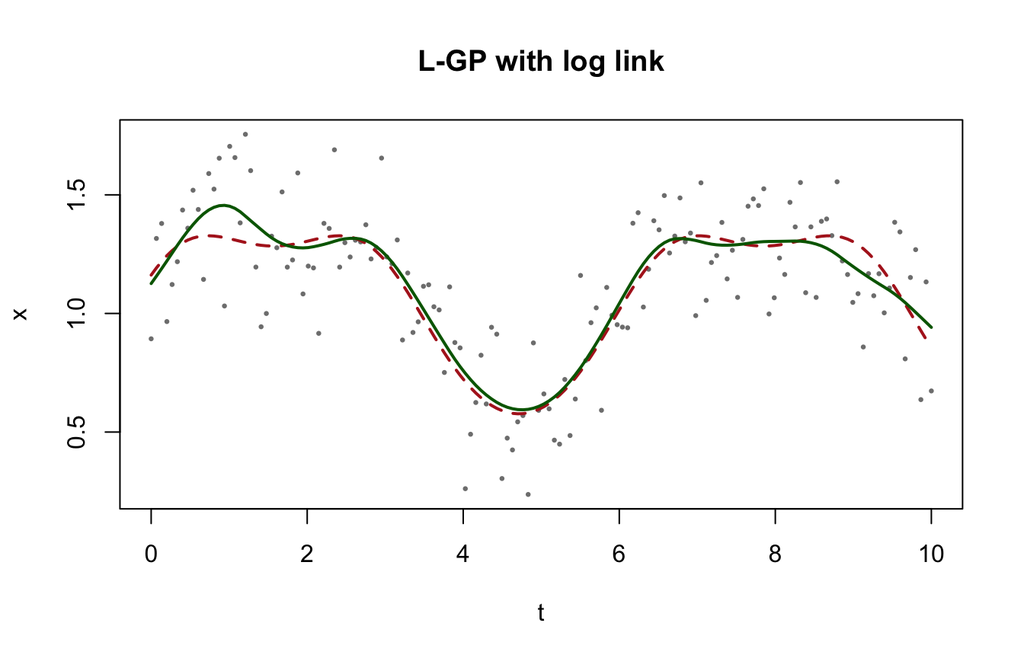

```r
plot(t, x_log, pch = 16, cex = 0.45, col = "grey50",
     xlab = "t", ylab = "x",
     main = "L-GP with log link")
lines(t, truth_log, col = "firebrick", lwd = 2, lty = 2)
lines(t, fit_log$posterior$mean, col = "darkgreen", lwd = 2)
```

# Role of `betaprec`

`betaprec` controls how the global polynomial coefficients are treated:

- `betaprec > 0`: proper Gaussian prior on the global coefficients.
- `betaprec = 0`: diffuse prior on the global coefficients.
- `betaprec < 0`: empirical-Bayes optimization mode for the global coefficients.

The following comparison shows how to create alternative setups:

```r
setup_diffuse <- LGP_setup(t = t, p = 2, num_knots = 30, betaprec = 0)
setup_proper  <- LGP_setup(t = t, p = 2, num_knots = 30, betaprec = 1)
setup_eb      <- LGP_setup(t = t, p = 2, num_knots = 30, betaprec = -1)

fit_diffuse <- ebnm_LGP_generator(setup_diffuse)(x, s)
fit_proper  <- ebnm_LGP_generator(setup_proper)(x, s)
fit_eb      <- ebnm_LGP_generator(setup_eb)(x, s)

c(
  diffuse = as.numeric(fit_diffuse$log_likelihood),
  proper = as.numeric(fit_proper$log_likelihood),
  eb = as.numeric(fit_eb$log_likelihood)
)
```

```
#>   diffuse    proper        eb
#> -39.62164 -41.82486 -38.51022
```

# Fixed Hyperparameters and Fixed Beta

When `fix_g = TRUE`, the L-GP fitter treats both the smoothing parameter and the global coefficients as fixed. If `beta_fixed` is omitted, it defaults to a zero vector.

```r
fit_fixed <- ebnm_LGP_generator(setup_eb)(
  x,
  s,
  g_init = LGP(0),
  fix_g = TRUE,
  beta_fixed = c(0.25, 0)
)

fit_fixed$fitted_g
```

```
#> $scale
#> [1] 0
#>
#> $beta
#> [1] 0.25 0.00
#>
#> $beta_prec
#> NULL
#>
#> attr(,"class")
#> [1] "LGP"
```

```r
fit_fixed$fitted_beta
```

```
#> [1] 0.25 0.00
```

# Useful Outputs

The L-GP fitter exposes several diagnostics that are helpful during method development:

```r
names(fit_identity)
```

```
#>  [1] "posterior"                    "fitted_g"
#>  [3] "fitted_beta"                  "beta_mode"
#>  [5] "beta_prec"                    "log_likelihood"
#>  [7] "log_likelihood_semantics"     "log_likelihood_stepA"
#>  [9] "log_likelihood_stepB_joint"   "log_likelihood_stepB_laplace"
#> [11] "posterior_sampler"            "data"
#> [13] "prior_family"                 "backend"
#> [15] "laplace_implementation"       "laplace_curvature"
#> [17] "link"                         "g_init"
```

```r
fit_identity$log_likelihood
```

```
#> 'log Lik.' -39.70482 (df=NULL)
```

```r
fit_identity$log_likelihood_stepA
```

```
#> 'log Lik.' -39.70482 (df=NULL)
```

```r
fit_identity$log_likelihood_stepB_joint
```

```
#> 'log Lik.' -56.05033 (df=NULL)
```

```r
fit_identity$log_likelihood_stepB_laplace
```

```
#> 'log Lik.' -39.70482 (df=NULL)
```

In routine use, the most important components are usually:

- `fit$posterior$mean`
- `fit$posterior$var`
- `fit$fitted_g`
- `fit$log_likelihood`